# PA1_template

Michael McGill

8/7/2020

## Loading required packages

```r
library(lubridate)
library(dplyr)
library(lattice)
```

## Loading and preprocessing the data

Download data and load into R

```r
url <- "https://d396qusza40orc.cloudfront.net/repdata%2Fdata%2Factivity.zip"
zip <- ".\\repdata_data_activity.zip"
file <- ".\\activity.csv"

if (!file.exists(zip)) download.file(url, zip)
if (!file.exists(file)) unzip(zip)

df <- read.csv(file, colClasses = c("numeric", "character", "character"))
```

Convert the date variable to a date format

```r
df$date <- ymd(df$date)
```

Create a time variable

```r
minutes <- substr(df$interval, nchar(df$interval) - 1, nchar(df$interval))
hours <- substr(df$interval, 1, nchar(df$interval) - 2)
hours <- sapply(hours, function(x) if(nchar(x) == 0) 0 else x)

df$time <- paste(hours, ":", minutes, sep = "") %>% hm() %>% as_date()
```

## What is mean total number of steps taken per day?

Calculate the total number of steps taken per day

```r
dailysum_df <- df %>% group_by(date) %>%
               summarise(dailysum = sum(steps, na.rm = TRUE))
```

Make a histogram of the total number of steps taken each day

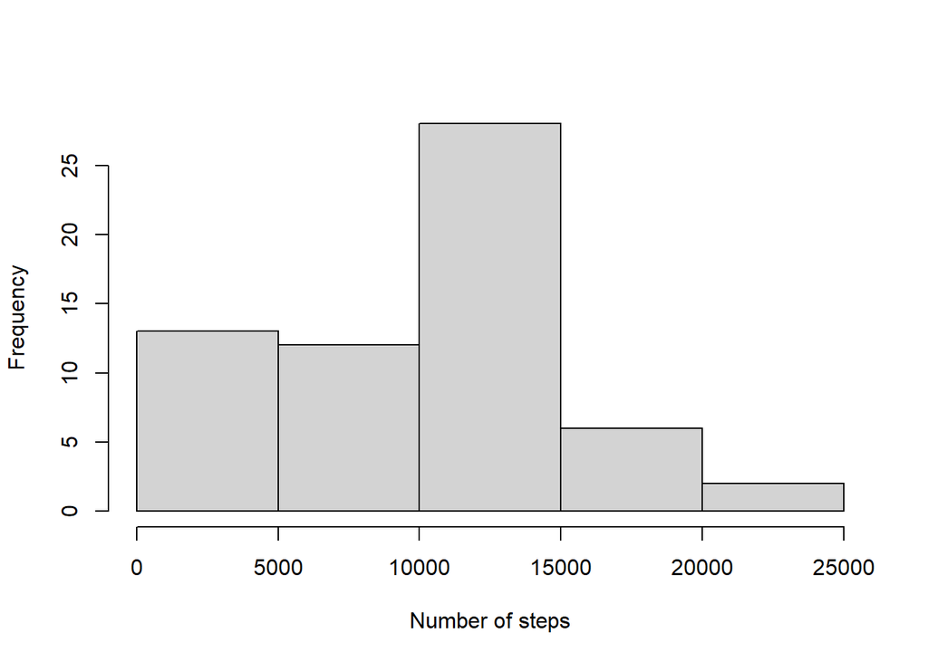

```r
hist(dailysum_df$dailysum, xlab = "Number of steps", main = NULL)
```

Calculate and report the mean and median of the total number of steps taken per day

```r
mean(dailysum_df$dailysum, na.rm = TRUE)
```

```
## [1] 9354.23
```

```r
median(dailysum_df$dailysum, na.rm = TRUE)
```

```
## [1] 10395
```

## What is the average daily activity pattern?

Make a time series plot of the 5-minute interval (x-axis) and the average number of steps taken, averaged across all days (y-axis)

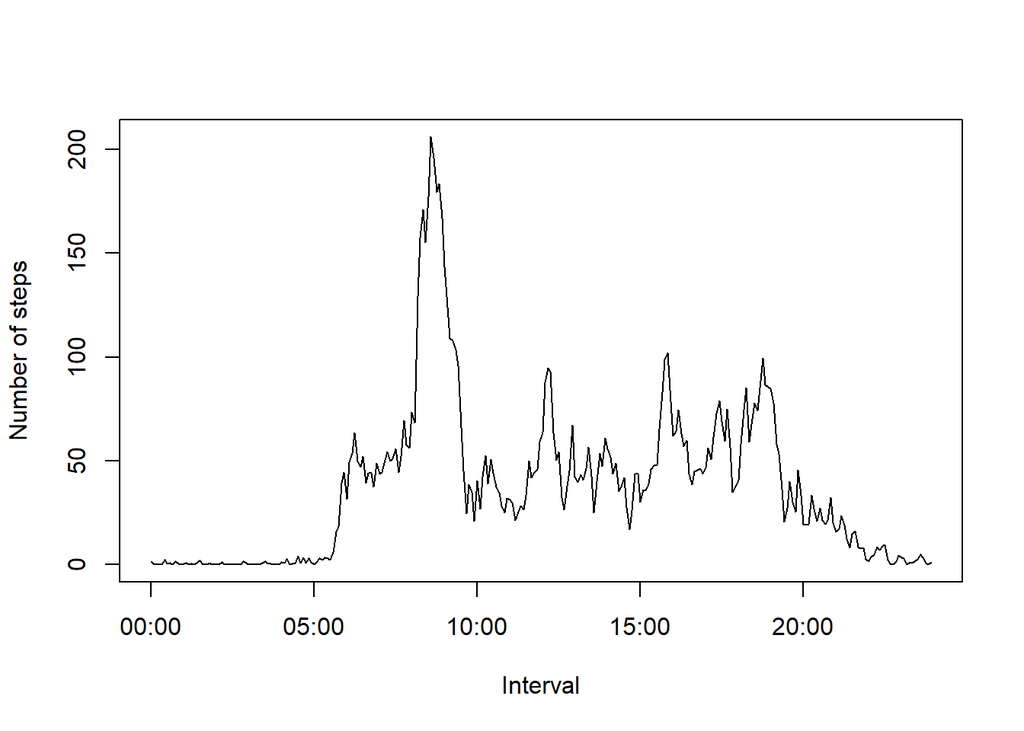

```r
intervalavg_df <- df %>% group_by(time) %>%
        summarise(intervalavg = mean(steps, na.rm = TRUE))

plot(intervalavg_df$time, intervalavg_df$intervalavg, type = "l",
     xlab = "Interval", ylab = "Number of steps",)
```

Which 5-minute interval, on average across all the days in the dataset, contains the maximum number of steps?

```r
intervalavg_df[[which.max(intervalavg_df$intervalavg),1]] %>% format("%H:%M")
```

```
## [1] "08:35"
```

## Imputing missing values

Calculate and report the total number of missing values in the dataset (i.e. the total number of rows with NAs)

```r
sum(is.na(df$steps))
```

```
## [1] 2304
```

Create a new dataset that is equal to the original dataset but with the missing data filled in. NAs will be replaced with the mean for that 5-minute interval.

```r
df_nonas <- df %>% group_by(time) %>%
                   mutate(steps = ifelse(is.na(steps),
                                         mean(steps, na.rm = TRUE),
                                         steps))
```

Calculate the total number of steps taken per day

```r
dailysum_df_nonas <- df_nonas %>% group_by(date) %>%
                     summarise(dailysum = sum(steps, na.rm = TRUE))
```

Make a histogram of the total number of steps taken each day.

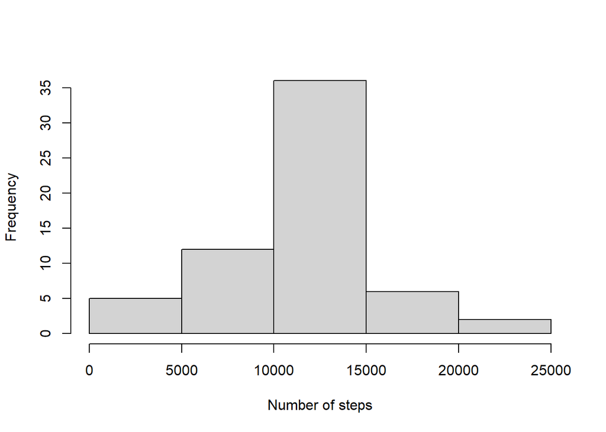

```r
hist(dailysum_df_nonas$dailysum, xlab = "Number of steps", main = NULL)
```

Calculate and report the mean and median of the total number of steps taken per day

```r
mean(dailysum_df_nonas$dailysum, na.rm = TRUE)
```

```
## [1] 10766.19
```

```r
median(dailysum_df_nonas$dailysum, na.rm = TRUE)
```

```
## [1] 10766.19
```

## Are there differences in activity patterns between weekdays and weekends?

```r
df_nonas$weekday <- ifelse(wday(df_nonas$date) != 6 & wday(df_nonas$date) != 7,
                           "weekday", "weekend")

df_nonas$weekday <- as.factor(df_nonas$weekday)
```

Make a panel plot containing a time series plot of the 5-minute interval (x-axis) and the average number of steps taken, averaged across all weekday days or weekend days (y-axis).

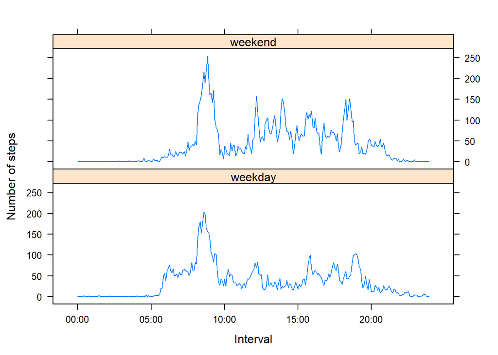

```r
intervalavg_df_nonas <- df_nonas %>% group_by(weekday, time) %>%
                        summarise(intervalavg = mean(steps, na.rm = TRUE))

xlabs <- c("00:00", "05:00", "10:00", "15:00", "20:00") %>%
         hm() %>% as_date()

xyplot(intervalavg ~ time | weekday, intervalavg_df_nonas,
       type = "l", layout = c(1,2),
       xlab = "Interval", ylab = "Number of steps",
       scales = list(x = list(at = xlabs,
                              labels = xlabs %>% format("%H:%M"))))
```